# Udacity - Communicate Data Findings (Dataset: Loan Data from Prosper

## by Mustafa Ahmed Hemdan

## Overview and Notes

This dataset contains data from over 100,000 prosper loans. Each row contains information about a specific loan that was funded through the Prosper marketplace.

#### What is prosper?

Prosper is a San Francisco based company in the peer-to-peer lending marketplace in the United States. Since 2005, Prosper has facilitated more than $15 billion in loans to more than 930,000 people.

## Factors affects the borrower’s APR or interest rate:

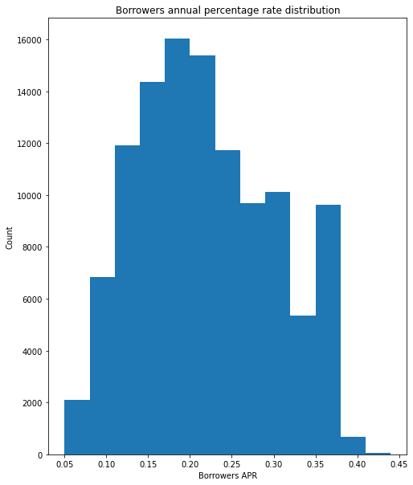

### Borrower APR by States :

- ME has the lowest APR at about 0.15 while AL has the highest APR at about 0.25

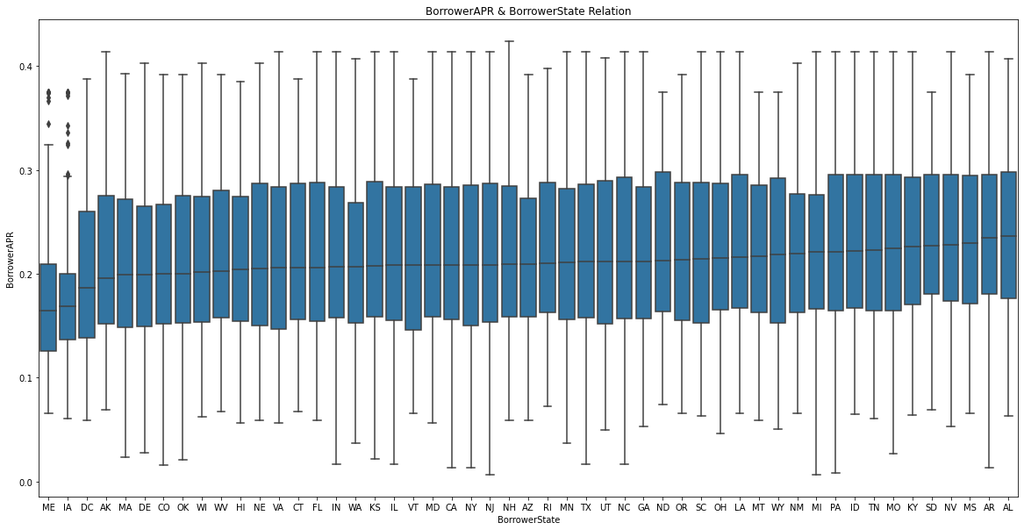

## Borrower APR by Listing Category :

- Personal loan is the lowest at 0.176 median APR, and Cosmetic Procedure is the highest at 0.272 median APR nearly 10 percentage points higher

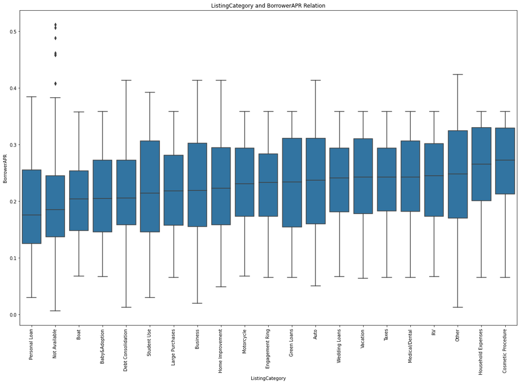